# Artificial Intelligence

## CA5 Second Phase

### Hamidreza Khodadadi 810197499

To optimize our output accuracy, we first normalize the data.

To build an optimal neural network, during its implementation, we test and analyze various possibilities and use the best and most optimal possibilities to create a nural network.

To analyze our network, we have used the following diagrams and reports.

```python
from google.colab import drive
drive.mount('/content/drive')
```

```python
!cp "/content/drive/MyDrive/xray.zip" .
```

```python
!unzip xray.zip
```

## Imported Libraries

```python
from tensorflow.keras import *
import matplotlib.pyplot as plt
from sklearn.metrics import classification_report
import numpy as np
import tensorboard
```

## Step 1:

```python
def reset_Dataset(_batch_size=32, _color_mode="grayscale", scale=None, _shuffle=True):
  dataGenerator = preprocessing.image.ImageDataGenerator(
      rescale=scale
  )
  print("TrainData: ")
  TrainData = dataGenerator.flow_from_directory(
    "/content/Data/train",
    target_size = (80, 80),
    color_mode = _color_mode,
    batch_size = _batch_size,
    shuffle=_shuffle
  )

  print("TestData: ")
  TestData = dataGenerator.flow_from_directory(
    "/content/Data/test",
    target_size = (80, 80),
    color_mode = _color_mode,
    batch_size = _batch_size,
    shuffle=_shuffle
  )
  return TrainData, TestData

print("Shuffle Data:")
TrainData, TestData = reset_Dataset()
print()
print("Un Shuffle Data:")
TrainData_not_shuffle, TestData_not_shuffle = reset_Dataset(_shuffle=False)
```

```
Shuffle Data:
TrainData:
Found 5144 images belonging to 3 classes.
TestData:
Found 1288 images belonging to 3 classes.

Un Shuffle Data:
TrainData:
Found 5144 images belonging to 3 classes.
TestData:
Found 1288 images belonging to 3 classes.
```

## Step 2:

### TrainData:

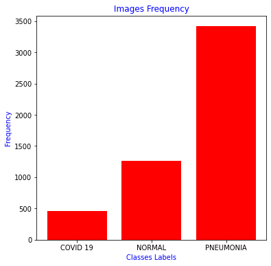

```python
classes_labels = {0:"COVID 19", 1:"NORMAL", 2:"PNEUMONIA"}

x = [classes_labels[i] for i in range(len(classes_labels))]
y = [int(0) for i in range(len(classes_labels))]

for i in TrainData.classes:
  y[i] += 1

plt.figure(figsize = (6, 6))
plt.bar(x, y, color = 'red')
plt.title("Images Frequency", color = 'blue')
plt.xlabel("Classes Labels", color = 'blue')
plt.ylabel("Frequency", color = 'blue')
plt.show()
```

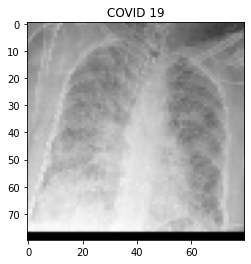

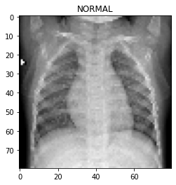

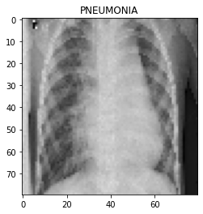

```python
labels = [classes_labels[i] for i in range(len(classes_labels))]
batch_images, batch_labels = TrainData.next()

counter = int(0)

for image, label in zip(batch_images, batch_labels):
  if counter == TrainData.num_classes:
    break
  elif label[counter] == 1:
    plt.imshow(image.reshape(80, 80), cmap='gray')
    plt.title(labels[counter])
    plt.show()
    counter += 1
  else:
    continue
```

### TestData:

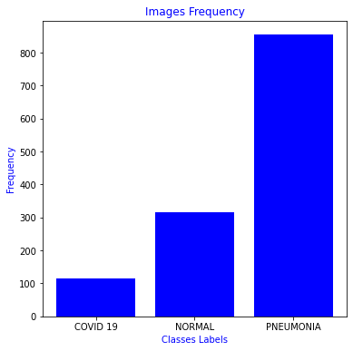

```python
x = [classes_labels[i] for i in range(len(classes_labels))]
y = [int(0) for i in range(len(classes_labels))]

for i in TestData.classes:
  y[i] += 1

plt.figure(figsize = (6, 6))
plt.bar(x, y, color = 'blue')
plt.title("Images Frequency", color = 'blue')
plt.xlabel("Classes Labels", color = 'blue')
plt.ylabel("Frequency", color = 'blue')
plt.show()
```

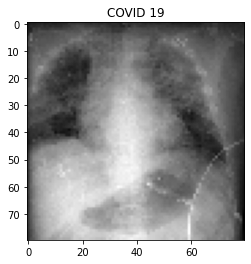

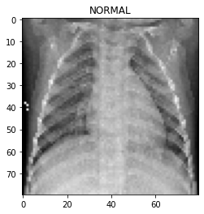

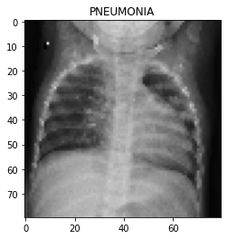

```python
labels = [classes_labels[i] for i in range(len(classes_labels))]
batch_images, batch_labels = TestData.next()

counter = int(0)

for image, label in zip(batch_images, batch_labels):
  if counter == TrainData.num_classes:
    break
  elif label[counter] == 1:
    plt.imshow(image.reshape(80, 80), cmap='gray')
    plt.title(labels[counter])
    plt.show()
    counter += 1
  else:
    continue
```

## Step 3:

```python
def create_neural_network(_activation, summary=False):
  input = layers.Input(shape=(80, 80, 1))
  output = layers.Flatten()(input)
  output = layers.Dense(1024, activation=_activation)(output)
  output = layers.Dense(1024, activation=_activation)(output)
  output = layers.Dense(3, activation="softmax")(output)
  model = models.Model(inputs=input, outputs=output)
  model.compile(optimizer=optimizers.SGD(learning_rate=0.01), loss="categorical_crossentropy", metrics=["accuracy"])
  if summary == True:
    model.summary()
  else:
    history = model.fit(TrainData, validation_data=TestData, epochs=10)
    return model, history
```

```python
create_neural_network("relu", summary=True)
```

```
Model: "model_3"
_________________________________________________________________
Layer (type)                 Output Shape              Param #
=================================================================
input_4 (InputLayer)         [(None, 80, 80, 1)]       0
_________________________________________________________________
flatten_3 (Flatten)          (None, 6400)              0
_________________________________________________________________
dense_9 (Dense)              (None, 1024)              6554624
_________________________________________________________________
dense_10 (Dense)             (None, 1024)              1049600
_________________________________________________________________
dense_11 (Dense)             (None, 3)                 3075
=================================================================
Total params: 7,607,299
Trainable params: 7,607,299
Non-trainable params: 0
_________________________________________________________________
```

From each neuron to all the neurons of the next layer is connected a weighted edge.

In the first hidden layer we have 6400 weight and 1 bias, and since we have 1024 neurons, we have 6400 x 1024 weight and 1024 bias.

In the second hidden layer we have 1024 to weight and 1 bias, and since we have 1024 to neurons, we have 1024 x 1024 to weight and 1024 to bias.

In the last layer we have 1024 weights and 1 bias, and since we have 3 neurons we have 1024 x 3 weights and 3 biases.

As a result, we have a total of 7607,299 parameters for neural network training.

```python
def print_report(history):
  labels = [classes_labels[i] for i in range(len(classes_labels))]
  y_true_train = TrainData_not_shuffle.labels
  y_predict_train = np.argmax(history.predict(TrainData_not_shuffle), axis=1)

  y_true_test = TestData_not_shuffle.labels
  y_predict_test = np.argmax(history.predict(TestData_not_shuffle), axis=1)

  print("TrainData: ")
  print(classification_report(y_true_train, y_predict_train, target_names=labels))
  print("TestData: ")
  print(classification_report(y_true_test, y_predict_test, target_names=labels))
```

```python
def visualization(history):
  plt.figure(figsize = (5, 5))

  plt.plot(history.history['loss'], label='Train')
  plt.plot(history.history['val_loss'], label='Test')

  plt.title("Model Loss")
  plt.xlabel("Epochs")
  plt.ylabel("Loss")

  plt.legend()
  plt.show()

  plt.figure(figsize = (5, 5))

  plt.plot(history.history['accuracy'], label='Train')
  plt.plot(history.history['val_accuracy'], label='Test')

  plt.title("Model Accuracy")
  plt.xlabel("Epochs")
  plt.ylabel("Accuracy")

  plt.legend()
  plt.show()
```

## Step 4:

```python
model, history = create_neural_network("relu")
```

```python
print_report(model)
```

```
TrainData:
              precision    recall  f1-score   support

    COVID 19       0.09      1.00      0.16       460
      NORMAL       0.00      0.00      0.00      1266
   PNEUMONIA       0.00      0.00      0.00      3418

    accuracy                           0.09      5144
   macro avg       0.03      0.33      0.05      5144
weighted avg       0.01      0.09      0.01      5144

TestData:
              precision    recall  f1-score   support

    COVID 19       0.09      1.00      0.17       116
      NORMAL       0.00      0.00      0.00       317
   PNEUMONIA       0.00      0.00      0.00       855

    accuracy                           0.09      1288
   macro avg       0.03      0.33      0.06      1288
weighted avg       0.01      0.09      0.01      1288
```

[figure not shown]

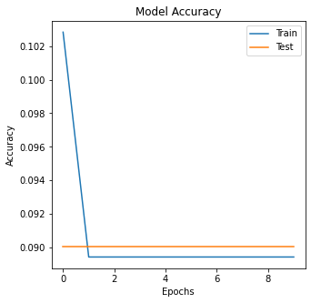

```python
visualization(history)
```

#### Question One:

The relu output range between zero and infinite positive.

Because we have not normalized the data, we have a gradient explosion and the value of the parameters overflows.

To solve this problem, we need to normalize the data.

```python
model, history = create_neural_network("tanh")
```

```python
print_report(model)
```

```
TrainData:
              precision    recall  f1-score   support

    COVID 19       0.00      0.00      0.00       460
      NORMAL       0.00      0.00      0.00      1266
   PNEUMONIA       0.66      1.00      0.80      3418

    accuracy                           0.66      5144
   macro avg       0.22      0.33      0.27      5144
weighted avg       0.44      0.66      0.53      5144

TestData:
              precision    recall  f1-score   support

    COVID 19       0.00      0.00      0.00       116
      NORMAL       0.00      0.00      0.00       317
   PNEUMONIA       0.66      1.00      0.80       855

    accuracy                           0.66      1288
   macro avg       0.22      0.33      0.27      1288
weighted avg       0.44      0.66      0.53      1288
```

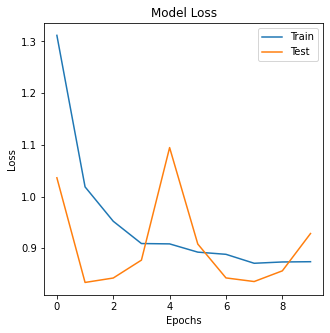

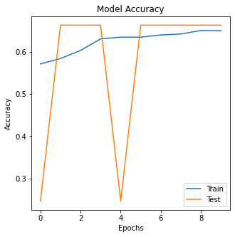

```python
visualization(history)
```

#### Question Two:

The tanh output range is from negative one to positive one, and if the input tends to infinity, the output of the function tends to one, so we will not have the overflow problem.

But the slope of the length changes relative to the step width decreases and the derivative of the tanh function tends to zero, which causes network learning to be incomplete and the neural network to not work well on all data.

To solve this problem, it will be useful to normalize the data because the value of the derivative of the hyperbolic tangent function will be zero as much as possible.

#### Question Three:

The reason for the different observations about the two functions is due to the different output intervals of these two functions as well as the input range of these two functions.

The common denominator of both our models and solutions is that the input data of both of them need to be normalized in order for the network to be well trained.

## Step 5:

In this section, although the structure we have calculates the value of F1 to be about 90%, I used two functions to get the maximum value for F1.

At first, I changed the activation function to a hyperbolic tangent, but I did not get the desired result.

Then I changed the structure of the neural network by changing the number of layers and the number of neurons in each layer and reached f1 about 95%.

```python
TrainData, TestData = reset_Dataset(scale=1.0/255.0, _shuffle=True)
TrainData_not_shuffle, TestData_not_shuffle = reset_Dataset(scale=1.0/255.0, _shuffle=False)
```

```
TrainData:
Found 5144 images belonging to 3 classes.
TestData:
Found 1288 images belonging to 3 classes.
TrainData:
Found 5144 images belonging to 3 classes.
TestData:
Found 1288 images belonging to 3 classes.
```

```python
model, history = create_neural_network("relu")
```

```python
print_report(model)
```

```
TrainData:
              precision    recall  f1-score   support

    COVID 19       0.87      0.92      0.89       460
      NORMAL       0.89      0.89      0.89      1266
   PNEUMONIA       0.96      0.95      0.95      3418

    accuracy                           0.93      5144
   macro avg       0.90      0.92      0.91      5144
weighted avg       0.93      0.93      0.93      5144

TestData:
              precision    recall  f1-score   support

    COVID 19       0.87      0.95      0.91       116
      NORMAL       0.90      0.91      0.91       317
   PNEUMONIA       0.97      0.95      0.96       855

    accuracy                           0.94      1288
   macro avg       0.91      0.94      0.92      1288
weighted avg       0.94      0.94      0.94      1288
```

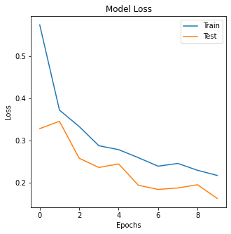

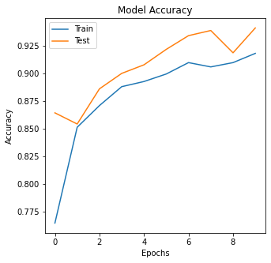

```python
visualization(history)
```

```python
model, history = create_neural_network("tanh")
```

```python
print_report(model)
```

```
TrainData:
              precision    recall  f1-score   support

    COVID 19       0.95      0.85      0.90       460
      NORMAL       0.86      0.89      0.88      1266
   PNEUMONIA       0.95      0.95      0.95      3418

    accuracy                           0.93      5144
   macro avg       0.92      0.90      0.91      5144
weighted avg       0.93      0.93      0.93      5144

TestData:
              precision    recall  f1-score   support

    COVID 19       0.96      0.84      0.89       116
      NORMAL       0.88      0.92      0.90       317
   PNEUMONIA       0.96      0.96      0.96       855

    accuracy                           0.94      1288
   macro avg       0.93      0.91      0.92      1288
weighted avg       0.94      0.94      0.94      1288
```

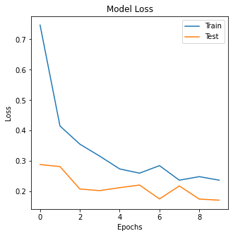

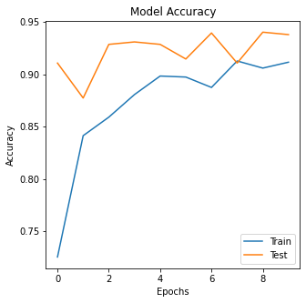

```python
visualization(history)
```

```python
def create_neural_network_with_extra_layers(_activation, epochs=10, summary=False, optimizer=optimizers.SGD(learning_rate=0.01)
    , loss="categorical_crossentropy"):
  input = layers.Input(shape=(80, 80, 1))
  output = layers.Flatten()(input)
  output = layers.Dense(2048, activation=_activation)(output)
  output = layers.Dense(4096, activation=_activation)(output)
  output = layers.Dense(1024, activation=_activation)(output)
  output = layers.Dense(3, activation="softmax")(output)
  model = models.Model(inputs=input, outputs=output)
  model.compile(optimizer=optimizer, loss=loss, metrics=["accuracy"])
  if summary == True:
    model.summary()
  else:
    history = model.fit(TrainData, validation_data=TestData, epochs=epochs)
    return model, history
```

```python
model, history = create_neural_network_with_extra_layers("relu")
```

```python
print_report(model)
```

```
TrainData:
              precision    recall  f1-score   support

    COVID 19       0.94      0.90      0.92       460
      NORMAL       0.93      0.85      0.88      1266
   PNEUMONIA       0.94      0.97      0.96      3418

    accuracy                           0.94      5144
   macro avg       0.93      0.91      0.92      5144
weighted avg       0.94      0.94      0.94      5144

TestData:
              precision    recall  f1-score   support

    COVID 19       0.95      0.92      0.93       116
      NORMAL       0.94      0.88      0.91       317
   PNEUMONIA       0.95      0.97      0.96       855

    accuracy                           0.95      1288
   macro avg       0.94      0.93      0.94      1288
weighted avg       0.95      0.95      0.95      1288
```

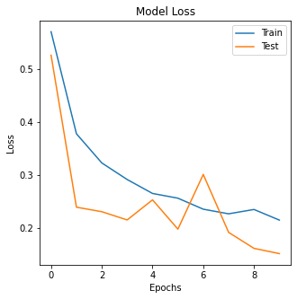

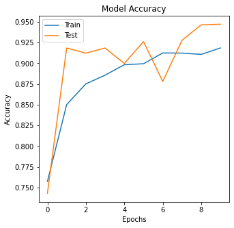

```python
visualization(history)
```

## Step 6:

#### Question One:

In general, we use optimizers to optimize and fix problems during neural network training operations.

Momentum is a parameter like the learning rate parameter.

Because our data contains noise data, we may make an error in updating the weights and get stuck in the local minimums and the network training will stop.

This parameter helps to cross the local minimums to continue the progress of network training.

#### Question Two:

```python
model, history = create_neural_network_with_extra_layers("relu", optimizer=optimizers.SGD(learning_rate=0.01, momentum=0.5))
```

```python
print_report(model)
```

```
TrainData:
              precision    recall  f1-score   support

    COVID 19       0.95      0.92      0.93       460
      NORMAL       0.96      0.79      0.87      1266
   PNEUMONIA       0.92      0.99      0.95      3418

    accuracy                           0.93      5144
   macro avg       0.94      0.90      0.92      5144
weighted avg       0.93      0.93      0.93      5144

TestData:
              precision    recall  f1-score   support

    COVID 19       0.95      0.91      0.93       116
      NORMAL       0.95      0.84      0.89       317
   PNEUMONIA       0.93      0.98      0.96       855

    accuracy                           0.94      1288
   macro avg       0.95      0.91      0.93      1288
weighted avg       0.94      0.94      0.94      1288
```

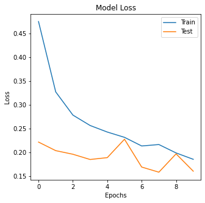

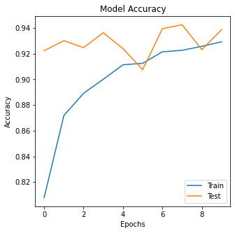

```python
visualization(history)
```

```python
model, history = create_neural_network_with_extra_layers("relu", optimizer=optimizers.SGD(learning_rate=0.01, momentum=0.9))
```

```python
print_report(model)
```

```
TrainData:
              precision    recall  f1-score   support

    COVID 19       0.93      0.90      0.91       460
      NORMAL       0.97      0.73      0.83      1266
   PNEUMONIA       0.90      0.99      0.94      3418

    accuracy                           0.92      5144
   macro avg       0.93      0.87      0.90      5144
weighted avg       0.92      0.92      0.91      5144

TestData:
              precision    recall  f1-score   support

    COVID 19       0.99      0.88      0.93       116
      NORMAL       0.95      0.77      0.85       317
   PNEUMONIA       0.91      0.99      0.95       855

    accuracy                           0.92      1288
   macro avg       0.95      0.88      0.91      1288
weighted avg       0.93      0.92      0.92      1288
```

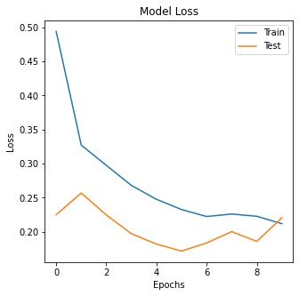

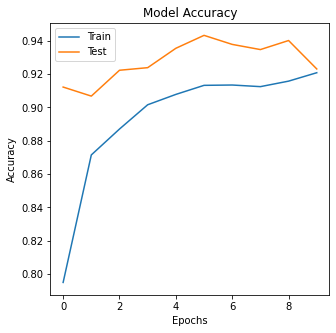

```python
visualization(history)
```

```python
model, history = create_neural_network_with_extra_layers("relu", optimizer=optimizers.SGD(learning_rate=0.01, momentum=0.99))
```

```python
print_report(model)
```

```
TrainData:
              precision    recall  f1-score   support

    COVID 19       0.00      0.00      0.00       460
      NORMAL       0.00      0.00      0.00      1266
   PNEUMONIA       0.66      1.00      0.80      3418

    accuracy                           0.66      5144
   macro avg       0.22      0.33      0.27      5144
weighted avg       0.44      0.66      0.53      5144

TestData:
              precision    recall  f1-score   support

    COVID 19       0.00      0.00      0.00       116
      NORMAL       0.00      0.00      0.00       317
   PNEUMONIA       0.66      1.00      0.80       855

    accuracy                           0.66      1288
   macro avg       0.22      0.33      0.27      1288
weighted avg       0.44      0.66      0.53      1288
```

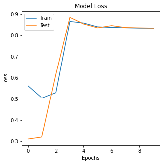

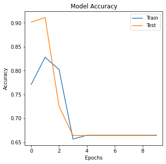

```python
visualization(history)
```

As you can see, the optimal value for the momentum parameter is 0.5, and the higher the value, the farther we get from the optimal answer.

The small value of the momentum parameter causes the training to face the problem again and get caught in the local minimums and not pass them.

And a large value for the momentum parameter increases the speed of updating the weights and takes us away from the desired and optimal result.

Here the value of 0.5 gives us the desired output.

#### Question Three:

No, too much value for the momentum takes us away from the desired result.

And instead of jumping on local minima, he jumps on ideal weights.

#### Question Four:

Using the Adam optimizer may get us to the answer sooner but is less accurate than the sgd parameter.

That is, Adam's optimizer is faster but not more efficient.

```python
model, history = create_neural_network_with_extra_layers("relu", optimizer=optimizers.Adam(learning_rate=0.001))
```

```python
print_report(model)
```

```
TrainData:
              precision    recall  f1-score   support

    COVID 19       0.91      0.78      0.84       460
      NORMAL       0.98      0.62      0.76      1266
   PNEUMONIA       0.86      0.99      0.92      3418

    accuracy                           0.88      5144
   macro avg       0.92      0.80      0.84      5144
weighted avg       0.89      0.88      0.88      5144

TestData:
              precision    recall  f1-score   support

    COVID 19       0.95      0.78      0.86       116
      NORMAL       0.97      0.69      0.81       317
   PNEUMONIA       0.88      0.99      0.93       855

    accuracy                           0.90      1288
   macro avg       0.93      0.82      0.87      1288
weighted avg       0.91      0.90      0.89      1288
```

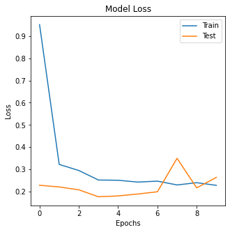

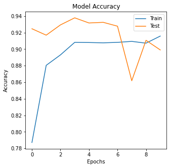

```python
visualization(history)
```

## Step 7:

#### Question One:

```python
model, history = create_neural_network_with_extra_layers("relu", epochs=20, optimizer=optimizers.Adam(learning_rate=0.001))
```

```python
print_report(model)
```

```
TrainData:
              precision    recall  f1-score   support

    COVID 19       0.87      0.97      0.92       460
      NORMAL       0.86      0.94      0.90      1266
   PNEUMONIA       0.98      0.93      0.95      3418

    accuracy                           0.94      5144
   macro avg       0.90      0.95      0.92      5144
weighted avg       0.94      0.94      0.94      5144

TestData:
              precision    recall  f1-score   support

    COVID 19       0.87      0.95      0.91       116
      NORMAL       0.86      0.96      0.91       317
   PNEUMONIA       0.98      0.93      0.95       855

    accuracy                           0.94      1288
   macro avg       0.90      0.94      0.92      1288
weighted avg       0.94      0.94      0.94      1288
```

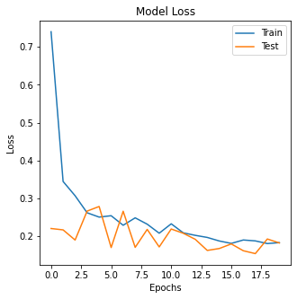

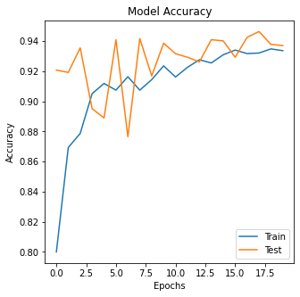

```python
visualization(history)
```

#### Question Two:

We need enough epochs to train an optimal neural network.

Because network performance improves step by step.

This means that we need to review and analyze the training data several times and update the weights, so that the weights are updated each time and get closer to their optimal value.

#### Question Three:

Using a large number of epochs is not necessarily appropriate.

Because it increases the training time of the model and reduces the training speed of the neural network, and that it increases the possibility of the model becoming orphaned, it means that our model is trained on noise data and the model works very well on training data but does not work well on test data.

To avoid this problem, the training process should be stopped before reducing the accuracy of the model on the test data.

## Step 8:

```python
model, history = create_neural_network_with_extra_layers("relu", epochs=20, optimizer=optimizers.Adam(learning_rate=0.001), loss="mse")
```

```python
print_report(model)
```

```
TrainData:
              precision    recall  f1-score   support

    COVID 19       0.00      0.00      0.00       460
      NORMAL       0.00      0.00      0.00      1266
   PNEUMONIA       0.66      1.00      0.80      3418

    accuracy                           0.66      5144
   macro avg       0.22      0.33      0.27      5144
weighted avg       0.44      0.66      0.53      5144

TestData:
              precision    recall  f1-score   support

    COVID 19       0.00      0.00      0.00       116
      NORMAL       0.00      0.00      0.00       317
   PNEUMONIA       0.66      1.00      0.80       855

    accuracy                           0.66      1288
   macro avg       0.22      0.33      0.27      1288
weighted avg       0.44      0.66      0.53      1288
```

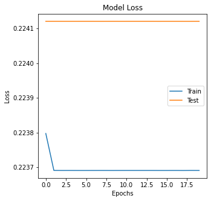

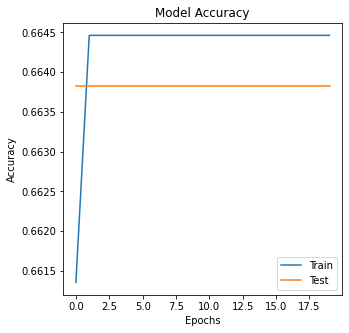

```python
visualization(history)
```

#### Question One:

As you can see, the accuracy and parameters of F1, recall and precision are drastically reduced, and for two of the classes we have the value of F1 equal to zero.

#### Question Two:

Because in mse it is assumed that our data has a normal or Gaussian distribution, it will not be useful in classification problems and will not give us optimal output and its application is in regression problems.

And that models like the mse probability model, which distinguish the correct class with little difference, will not necessarily give us the desired optimal result.

And in these models, the amount of loss may be calculated incorrectly.

## Step 9:

These two models prevent the neural network from orphiting the data.

In L2 method, sudden weight gain is prevented and its function is to try to keep the weights small.

In the dropout method, a small portion of the input data is excluded from the calculations based on a probabilistic parameter.

As a result, the number of uses and the amount of probabilistic parameters of this function should be normal, and if a lot of data is taken out of the calculations, the accuracy of the model will decrease.

```python
def create_neural_network_with_regularizer(_activation, epochs=10, summary=False, optimizer=optimizers.SGD(learning_rate=0.01)
    , loss="categorical_crossentropy"):
  input = layers.Input(shape=(80, 80, 1))
  output = layers.Flatten()(input)
  output = layers.Dense(2048, activation=_activation, kernel_regularizer=regularizers.L2(l2=0.0001))(output)
  output = layers.Dense(4096, activation=_activation, kernel_regularizer=regularizers.L2(l2=0.0001))(output)
  output = layers.Dense(1024, activation=_activation, kernel_regularizer=regularizers.L2(l2=0.0001))(output)
  output = layers.Dense(3, activation="softmax", kernel_regularizer=regularizers.L2(l2=0.0001))(output)
  model = models.Model(inputs=input, outputs=output)
  model.compile(optimizer=optimizer, loss=loss, metrics=["accuracy"])
  if summary == True:
    model.summary()
  else:
    history = model.fit(TrainData, validation_data=TestData, epochs=epochs)
    return model, history
```

```python
model, history = create_neural_network_with_regularizer("relu", epochs=20, optimizer=optimizers.Adam(learning_rate=0.001))
```

```python
print_report(model)
```

```
TrainData:
              precision    recall  f1-score   support

    COVID 19       0.91      0.95      0.93       460
      NORMAL       0.96      0.85      0.90      1266
   PNEUMONIA       0.95      0.98      0.96      3418

    accuracy                           0.95      5144
   macro avg       0.94      0.93      0.93      5144
weighted avg       0.95      0.95      0.95      5144

TestData:
              precision    recall  f1-score   support

    COVID 19       0.96      0.94      0.95       116
      NORMAL       0.94      0.88      0.91       317
   PNEUMONIA       0.95      0.98      0.96       855

    accuracy                           0.95      1288
   macro avg       0.95      0.93      0.94      1288
weighted avg       0.95      0.95      0.95      1288
```

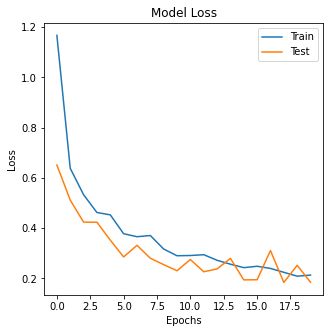

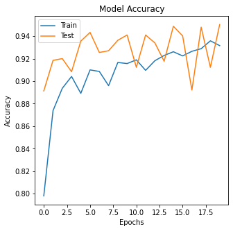

```python
visualization(history)
```

```python
def create_neural_network_with_dropout(_activation, epochs=10, summary=False, optimizer=optimizers.SGD(learning_rate=0.01)
    , loss="categorical_crossentropy"):
  input = layers.Input(shape=(80, 80, 1))
  output = layers.Flatten()(input)
  output = layers.Dense(2048, activation=_activation)(output)
  output = layers.Dropout(rate=0.1)(output)
  output = layers.Dense(4096, activation=_activation)(output)
  output = layers.Dropout(rate=0.1)(output)
  output = layers.Dense(1024, activation=_activation)(output)
  output = layers.Dropout(rate=0.1)(output)
  output = layers.Dense(3, activation="softmax")(output)
  model = models.Model(inputs=input, outputs=output)
  model.compile(optimizer=optimizer, loss=loss, metrics=["accuracy"])
  if summary == True:
    model.summary()
  else:
    history = model.fit(TrainData, validation_data=TestData, epochs=epochs)
    return model, history
```

```python
model, history = create_neural_network_with_dropout("relu", epochs=20, optimizer=optimizers.Adam(learning_rate=0.001))
```

```python
print_report(model)
```

```
TrainData:
              precision    recall  f1-score   support

    COVID 19       0.71      0.95      0.81       460
      NORMAL       0.92      0.83      0.88      1266
   PNEUMONIA       0.95      0.94      0.95      3418

    accuracy                           0.92      5144
   macro avg       0.86      0.91      0.88      5144
weighted avg       0.92      0.92      0.92      5144

TestData:
              precision    recall  f1-score   support

    COVID 19       0.77      0.99      0.87       116
      NORMAL       0.95      0.90      0.92       317
   PNEUMONIA       0.97      0.95      0.96       855

    accuracy                           0.94      1288
   macro avg       0.90      0.95      0.92      1288
weighted avg       0.94      0.94      0.94      1288
```

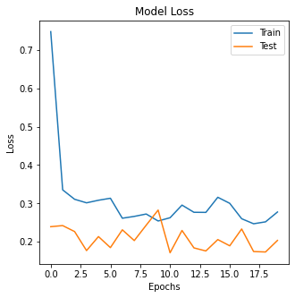

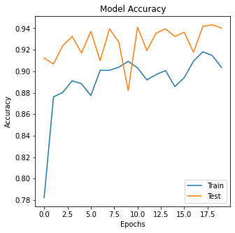

```python
visualization(history)
```